# Penguins PDA

# 1. Exploratory analysis

Explore the dataset using visualisations, and keep in mind the question you’re trying to answer above.

Write a short summary of the results.

```r
library(palmerpenguins)
library(tidyverse)
library(e1071)
library(infer)
penguins <- palmerpenguins::penguins
```

```r
summary(penguins)
```

```
      species          island    bill_length_mm  bill_depth_mm   flipper_length_mm
 Adelie   :152   Biscoe   :168   Min.   :32.10   Min.   :13.10   Min.   :172.0
 Chinstrap: 68   Dream    :124   1st Qu.:39.23   1st Qu.:15.60   1st Qu.:190.0
 Gentoo   :124   Torgersen: 52   Median :44.45   Median :17.30   Median :197.0
                                 Mean   :43.92   Mean   :17.15   Mean   :200.9
                                 3rd Qu.:48.50   3rd Qu.:18.70   3rd Qu.:213.0
                                 Max.   :59.60   Max.   :21.50   Max.   :231.0
                                 NA's   :2       NA's   :2       NA's   :2
  body_mass_g       sex           year
 Min.   :2700   female:165   Min.   :2007
 1st Qu.:3550   male  :168   1st Qu.:2007
 Median :4050   NA's  : 11   Median :2008
 Mean   :4202                Mean   :2008
 3rd Qu.:4750                3rd Qu.:2009
 Max.   :6300                Max.   :2009
 NA's   :2
```

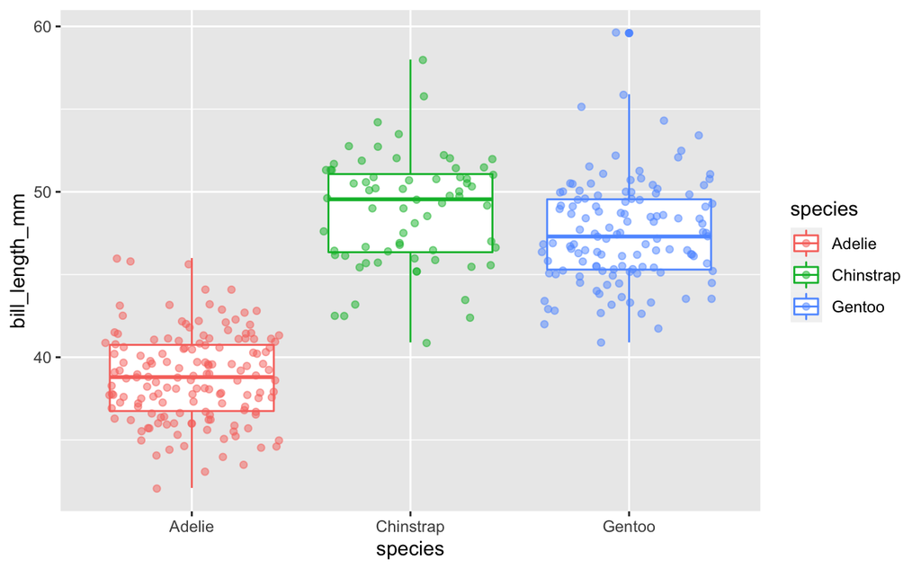

```r
penguins %>%
  ggplot(aes(species,bill_length_mm))+
  geom_boxplot(aes(colour = species))+
  geom_jitter(aes(colour = species), alpha = 0.5)
```

```
From the graph above, on average, chinstrap has the longest bill and
adelie has the shortest. gentoo and chinstrap looks very similar.
```

# 2. Summary statistics

Calculate the following summary statistics to describe bill length for each species:

measures of centrality (mean & median) spread (standard deviation) skewness (you can use the skewness() function from the e1071 package) Write a short summary of the results.

## 4.4 Summary statistics including measures of centrality, spread and skewness

```r
penguins %>%
  group_by(species) %>%
  summarise(mean_bill = mean(bill_length_mm, na.rm = TRUE),
            median = median(bill_length_mm, na.rm = TRUE),
            skewness = skewness(bill_length_mm, na.rm = TRUE, type = 1)
            )
```

| species | mean_bill | median | skewness |
| --- | --- | --- | --- |
| Adelie | 38.79139 | 38.80 | 0.16006382 |
| Chinstrap | 48.83382 | 49.55 | -0.08856427 |
| Gentoo | 47.50488 | 47.30 | 0.64316334 |

```
From the table above, the average bill_lenght matachs with the box_plot(Chinstrap has the longest then gentoo and adelie),
for the distribution, chinstrp and adelie are symmtric,
and gentoo are moderately right skewed,
on average, chinstrap has the longest bill and
adelie has the shortest. gentoo and chinstrap looks very similar.
```

# 3. Hypothesis test & probability

Perform a suitable hypothesis test to check whether the mean bill length of Gentoo is significantly longer than the mean bill length of Adelie.

Visualise the p-value on the null distribution. Write an interpretation of your findings.

## 4.1 Exploratory data analysis and targeted data analysis (hypothesis testing)

## 4.3 Probability and probability distributions

My Null(H0) and alternative(H1) hypothesis as below, my alpha level is 0.05
$$N0: \mu_{gentoo\ bill\ length} = \mu_{adelie\ bill\ length} \\
N1: \mu_{gentoo\ bill\ length} > \mu_{adelie\ bill\ length}$$

```r
null_distribution <- penguins %>%
  filter(species %in% c("Adelie", "Gentoo")) %>%
  specify(bill_length_mm ~ species) %>%
  hypothesise(null = 'independence') %>%
  generate(rep = 1000, type = 'permute') %>%
  calculate(stat = "diff in means", order = c('Gentoo', 'Adelie'))
```

```
Dropping unused factor levels Chinstrap from the supplied explanatory variable 'species'.
Warning: Removed 2 rows containing missing values.
```

```r
null_distribution
```

```
Response: bill_length_mm (numeric)
Explanatory: species (factor)
Null Hypothesis: independence
```

| replicate | stat |
| --- | --- |
| 1 | -1.3890916922 |
| 2 | 0.1097722500 |
| 3 | 0.6629946697 |
| 4 | 0.4166262855 |
| 5 | -0.0097237926 |
| 6 | -0.0790610025 |
| 7 | 0.8533031820 |
| 8 | 0.4490820008 |
| 9 | -0.5142626393 |
| 10 | 0.5139934313 |

[output cut: 990 more lines]

null_distribution <- penguins %>% filter(species %in% c(“Adelie”, “Gentoo”)) %>% #it’s only comparing adelie and gentoo

specify(bill_length_mm ~ species) %>% #it is the relationship between bill length and species we are testing,

hypothesise(null = ‘independence’) %>% #the null hypothesis is there is no relationship

generate(rep = 1000, type = ‘permute’) %>% #detaching the species from rows and then randomly assigning them back.

calculate(stat = “diff in means”, order = c(‘Gentoo’, ‘Adelie’))#our sample stat is mean of gentoo - mean of adelie

```r
observed_stats <- penguins %>%
  filter(species %in% c("Adelie", "Gentoo")) %>%
  specify(bill_length_mm ~ species) %>%
  calculate(stat = "diff in means", order = c('Gentoo', 'Adelie'))
```

```
Dropping unused factor levels Chinstrap from the supplied explanatory variable 'species'.
Warning: Removed 2 rows containing missing values.
```

```r
observed_stats
```

```
Response: bill_length_mm (numeric)
Explanatory: species (factor)
```

| stat |
| --- |
| 8.713487 |

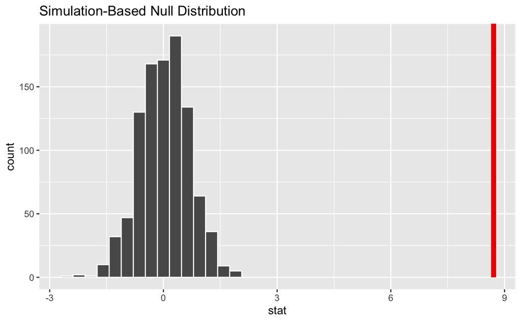

```r
null_distribution %>%
  visualise()+
  shade_p_value(obs_stat = observed_stats, direction = "right")
```

```r
p_value <- null_distribution %>%
  get_p_value(obs_stat = observed_stats, direction = "right")
p_value
```

| p_value |
| --- |
| 0 |

```
p_value is how likely it is to see a result as extreme as observed result, if the null hypothesus is true.
we got p_value < 0.0001, this means it's not very likely to see a dataset such as ours, if the HO is true.
It is a lot less than our alpha level,
the difference is significant and we reject H0 and
found evidence to support H1.
```

Create a correlation matrix using GGally::ggcorr() that shows the correlation between bill length, bill depth, flipper length, and body mass across species. (Hint: you can add correlation coefficient labels to your plot if you look at the ?ggcorr help file)

Write a short summary of your results.

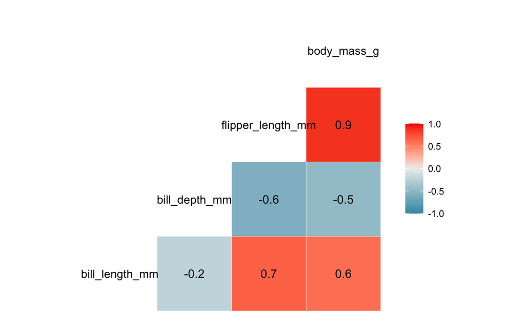

```
body mass and flipper length has a very strong possitive correlation,
body mass also has strong possitive correlation with bill length,
flipper length has a strong positive correlation with bill length,
bill length has a week negtive correlation with bill depth.
```

4.5 Concept of correlation and correlation matrices 4.8 Documenting analyses